# Bài tập lý thuyết tuần 3

> Họ và tên: Nguyễn Vạn Phúc Huy  
> MSSV: 23110163  
> Lớp: 23TTH (Sáng thứ 6)

### Bài tập:

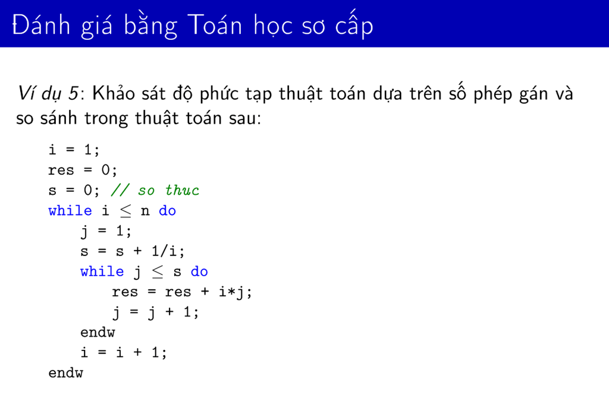

Bài làm

> Số phép gán

Trước hết ta có 3 phép gán:

```
i = 1;
res = 0;
s = 0;
```

Trong vòng lặp while i <= n thì mỗi vòng lặp ta luôn luôn có 3 phép gán sau:

```
j = 1;
s = s + 1/i;
i = i + 1;
```

Vì vậy, ta có 3n phép gán trong vòng lặp while i <= n.

Nhưng mà do s = s + 1/i nên s sẽ tăng dần theo i nên ở vòng lặp tiếp theo while j <= s trong vòng lặp while i <= n sẽ có số lần lặp là s = s + 1/i, tức là s sẽ tăng dần theo i. Do đó, số lần lặp của vòng while j <= s sẽ tăng dần theo i. Tức là $$s_i = 1 + 1/2 + 1/3 + ... + 1/i = \text{floor}( \sum_{k=1}^{i} \frac{1}{k})$$

Mà trong vòng lặp while j <= s thì có 2 phép gán là:

```
res = res + i*j;
j = j + 1;
```

Do đó, số phép gán trong vòng lặp while j <= s sẽ là $$2\text{floor}(\sum_{k=1}^{i} \frac{1}{k})$$ Khi kết hợp với vòng lặp while i <= n thì số phép gán trong vòng lặp while j <= s sẽ là $$2\sum_{i=1}^{n} \text{floor}(\sum_{k=1}^{i} \frac{1}{k})$$ Như vậy tổng số phép gán trong thuật toán sẽ là: $$3+ 3n + 2\sum_{i=1}^{n}\text{floor}( \sum_{k=1}^{i} \frac{1}{k})$$

> Số phép so sánh

Trong thuật toán trên, ta có 2 vòng lặp có so sánh là:

```
while i <= n
    ...
    while j <= s do
        ...
```

Ở while i <= n thì ta có n + 1 phép so sánh (vì khi i = n + 1 thì điều kiện i <= n sẽ sai nên ta có n + 1 phép so sánh)

Còn ở while j <= s trong vòng lặp while i <= n thì số lần lặp sẽ là $\sum_{i=1}^{n} ( \text{floor}(\sum_{k=1}^{i} \frac{1}{k}) + 1)$

Như vậy tổng số phép so sánh trong thuật toán sẽ là: $$ n + 1 + \sum_{i=1}^{n} ( \text{floor}(\sum_{k=1}^{i} \frac{1}{k}) + 1) = n + 1 + n + \sum_{i=1}^{n} \text{floor}(\sum_{k=1}^{i}\frac{1}{k})$$ $$ = 1 + 2n + \sum_{i=1}^{n} \text{floor}(\sum_{k=1}^{i}\frac{1}{k})$$

Mà ta đã biết rằng
$$\text{floor}( \sum_{k=1}^{i} \frac{1}{k}) \approx \ln(i) + \gamma \text{ với } \gamma \text{ là hằng số}$$ Do đó, ta có: $$ \sum_{i=1}^{n} \text{floor}( \sum_{k=1}^{i} \frac{1}{k}) \approx n \ln(n) + n\gamma$$ Như vậy, ta tính tổng của số phép so sánh và số phép gán trong thuật toán trên sẽ là: Tổng số phép gán + Tổng số phép so sánh = $$3+ 3n + 2\sum_{i=1}^{n} \text{floor}(\sum_{k=1}^{i} \frac{1}{k}) + 1 + 2n + \sum_{i=1}^{n} \text{floor} (\sum_{k=1}^{i} \frac{1}{k})$$ $$ = 4 + 5n + 3\sum_{i=1}^{n} \text{floor}(\sum_{k=1}^{i}\frac{1}{k})$$ $$ \approx 4 + 5n + 3(n \ln(n) + n\gamma)$$ $$ \approx 4 + 5n + 3n \ln(n) + 3n\gamma$$ $$ \approx O(n \ln(n))$$

Vậy thuật toán có độ phức tạp là $O(n \ln(n))$.